# IDS Midterm Notes 20/12/2025

## Tutorial 4 (30/10/2025)

- **Overview**
  - stringsAsFactors
  - geom_line()
    - linetype
  - scale_colour_manual()
  - theme_minimal()
  - theme()
    - plot.title
    - legend.title
    - element_text()
      - hjust
      - size
      - face
    - element_blank()
    - element_line()
    - axis.line.y.right
    - axis.ticks.y.right
    - axis.title.y.right
    - axis.text.y.right
  - data()
  - as.data.frame()
  - labs()
  - geom_smooth()
    - method, se, colour
  - scale_y_continuous
    - sec.axis
      - name
  - ~
  - shape
  - alpha

### Tutorial Code

stringsAsFactors determines whether character strings should be converted to factors (categorical variables)

```r
setwd("C:/Users/slee7/OneDrive - Imperial College London/Introduction to Data Science/Week 4")

uk_gdp_and_weeklyWage <- read.csv("Tutorial files/uk_gdp_and_weeklyWage_Pop.csv",
stringsAsFactors = F)

uk_gdp_and_weeklyWage <-   uk_gdp_and_weeklyWage %>%
  mutate(GDP_growth_rate = (GDP_m - lag(GDP_m)) / lag(GDP_m) * 100,
         weeklyWageQuantile = cut(Weekly_pay,
                                  quantile(Weekly_pay,
                                           probs = seq(0, 1, 0.25), type = 7),
                                  include.lowest = T, labels = F)
         )

uk_gdp_and_weeklyWage <- uk_gdp_and_weeklyWage %>%
  mutate(GDP_growth_rate_Quantile = cut(GDP_growth_rate,
                                        quantile(GDP_growth_rate,
                                                 probs = seq(0, 1, 0.25), type = 7, na.rm = T),
                                        include.lowest = T, labels = F)
         )
```

as.factor() converts data as categorical data instead of numeric or character string data

scale_colour_manual() sets manual values for the colour categorical factor in terms of a vector of colours

theme_minimal() sets a minimialistic theme with no background annotation to the ggplot object

theme() offers a way to customize the aesthetics of your plot

plot.title sets the title of the plot

legend.title sets the title of the legend

element_text() specifies that the non-data component will be text

hjust sets the horizontal justification between [0,1]

face is the font face (“plain”, “italic”, “bold”, “bold.italic”)

element_blank() draws nothing and assigns no space

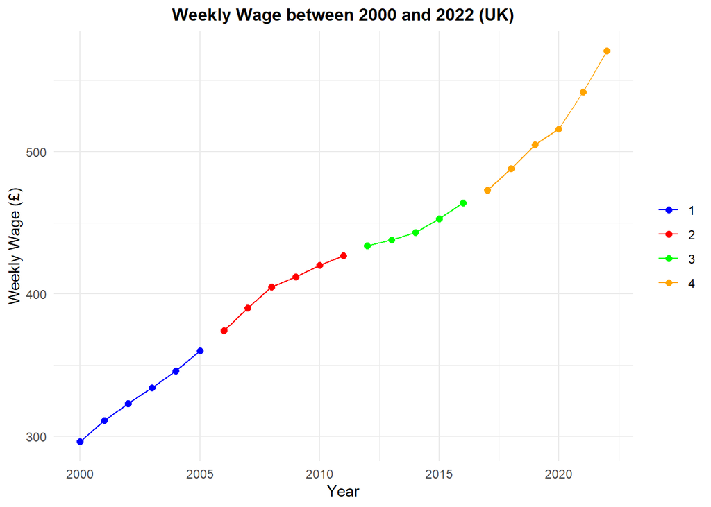

```r
uk_gdp_and_weeklyWage %>%
  mutate(weeklyWageQuantile = as.factor(weeklyWageQuantile)) %>%
  ggplot(aes(x = Year, y = Weekly_pay, colour = weeklyWageQuantile)) +
  geom_point(size = 2) +
  geom_line(aes(group = weeklyWageQuantile)) +
  xlab("Year") +
  ylab("Weekly Wage (£)") +
  ggtitle("Weekly Wage between 2000 and 2022 (UK)") +
  scale_colour_manual(values = c("blue", "red", "green", "orange")) +
  theme_minimal() +
  theme(
    plot.title = element_text(hjust = 0.5, size = 12, face = "bold"),
    legend.title = element_blank()
    )
```

data() leads built-in or package-provided datasets into the current workspace

as.data.frame() coerces object (vector, list, matrix, or array) into a data frame

```r
data("LifeCycleSavings")
savings_data <- as.data.frame(LifeCycleSavings)
```

Data formatting (no new information learned)

```r
savings_data <- savings_data %>%
  mutate(savings_category = case_when(
    sr < 10 ~ "Low Savings",
    sr >= 10 & sr <= 20 ~ "Moderate Savings",
    sr > 20 ~ "High Savings"
    ))
```

labs() allow for another way to label instead of xlab(), ylab(), ggtitle(), etc.

Since colour mapping produces a legend by default, labs(colour=“Title”) renames that colour scale legend title

geom_smooth() plots a trend line that follows the method

“lm” method is the linear regression model

se is whether to display a confidence band around the trend line

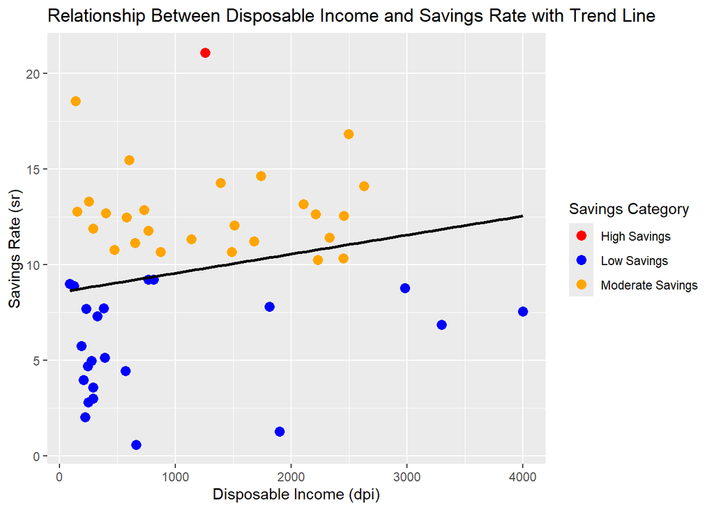

```r
savings_data %>%
  ggplot(aes(x = dpi, y = sr, colour = savings_category)) +
  geom_point(size = 3) +
  geom_smooth(method = "lm", se = FALSE, colour = "black") +
  scale_colour_manual(values = c("Low Savings" = "blue",
                                "Moderate Savings" = "orange",
                                "High Savings" = "red")) +
  labs(x = "Disposable Income (dpi)",
       y = "Savings Rate (sr)",
       title = "Relationship Between Disposable Income and Savings Rate with Trend Line",
       colour = "Savings Category")
```

### Additional Files

A scale factor may be estimated using the following but must have further empirical adjustments:
$$\text{scale_factor} = \frac{\max(\text{2nd dataset}) - \min(\text{2nd
dataset}))}{(\max(\text{1st dataset}) - \min(\text{1st dataset}))}$$

```r
uk_gdp_and_weeklyWage <- uk_gdp_and_weeklyWage %>%
  mutate(GDP_per_cap = GDP_m/Population*1000000)

scale_factor <- (max(uk_gdp_and_weeklyWage$GDP_per_cap) - min(uk_gdp_and_weeklyWage$GDP_per_cap)) / (max(uk_gdp_and_weeklyWage$Weekly_pay) - min(uk_gdp_and_weeklyWage$Weekly_pay))

scale_factor = scale_factor*2
```

You can have multiple lines in one plot by just adding more geometries by using “+”

alpha specifies the transparency, ranging from [0,1]

shape modifies the appearance of points

linetype modifies the appearance of lines

Additionally, you can add a second axis on the opposite side to show a different scale. This can be achieved through specifying sec.axis, which defines a one-to-one transformation of the primary scale.

`~` serves to introduce a one-sided formula, applying the transformation that comes afterwards. Since we have `~.*scale_factor`, this means `~` is a `function(x) = x * scale_factor`.

element_line() specifies that the non-data component will be a line

axis.line.y.right is the line along the right y-axis

axis.ticks.y.right are the ticks along the right y-axis

axis.title.y.right is the title of the right y-axis

axis.text.y.right is the text of the right y-axis

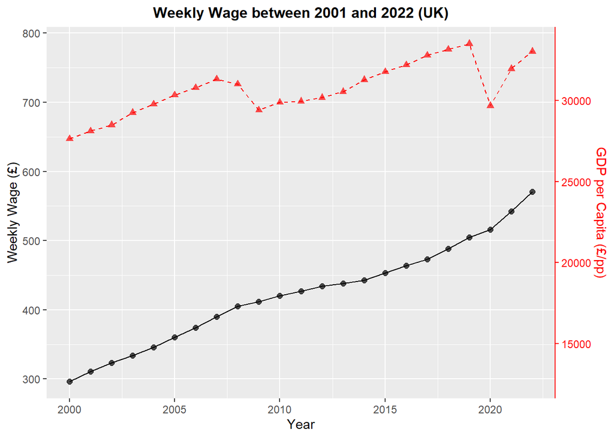

```r
uk_gdp_and_weeklyWage %>%
  ggplot(aes(x=Year)) +
  geom_point(aes(y=Weekly_pay), size = 2, alpha = 0.7, shape = 19) +
  geom_line(aes(y=Weekly_pay)) +
  geom_point(aes(y=GDP_per_cap/scale_factor), size = 2, colour = "red", alpha = 0.7, shape = 17) +
  geom_line(aes(y=GDP_per_cap/scale_factor), colour = "red", linetype = "dashed") +
  labs(title ="Weekly Wage between 2001 and 2022 (UK)",
       x = "Year",
       y = "Weekly Wage (£)") +
  scale_y_continuous(
    sec.axis = sec_axis(~. *scale_factor, name= "GDP per Capita (£/pp)")) +
  theme(axis.line.y.right = element_line(colour = "red"),
        axis.ticks.y.right = element_line(colour = "red"),
        axis.title.y.right = element_text(colour = "red"),
        axis.text.y.right = element_text(colour = "red")) +
  theme(
    plot.title = element_text(hjust = 0.5, size = 12, face = "bold")
    )
```

## Lecture 5 (3/11/2025)

- **Overview**
  - geom_abline()
    - intercept
  - lty
  - ggthemes package
    - theme_economist()
  - ggrepel package
    - geom_text_repel()
    - geom_label_repel()
  - ggpubr package
    - ggarrange
  - geom_histogram()
    - bins
  - geom_density
    - after_stat()
  - R Markdown
    - YAML header
    - Text formatting
    - Heading
    - Comments
    - Lists
    - Links
  - Version control
  - Git workflow
  - GitHub

If we wanted a line to represent the average murder rate by population, since we converted into log scale, $y=rx$ becomes $log(y) = log(r) + log(x)$ where the slope is 1 and the y-intercept is $log(r)$.

geom_abline() draws a line with intercept (a) and slope (b).

lty is the short form for linetype

Instead of labs(colour=“Title”), to change the legend, we can do scale_colour_discrete(name=“Title”) or theme(legend.title=element_text(“Title”))

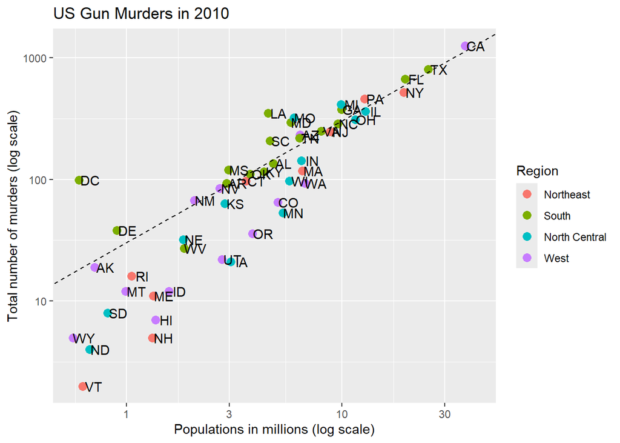

```r
r <- murders %>%
  summarise(rate = sum(total)/sum(population)*10^6) %>%
  pull(rate)

murders %>% ggplot(aes(x = population/10^6, y = total, label = abb)) +
  geom_point(aes(
    col = region),
    size = 3
    ) +
  geom_abline(intercept = log10(r), lty = 2,) +
  geom_text(nudge_x = 0.05) +
  scale_x_log10() +
  scale_y_log10() +
  xlab("Populations in millions (log scale)") +
  ylab("Total number of murders (log scale)") +
  ggtitle("US Gun Murders in 2010") +
  scale_colour_discrete(name = "Region")
```

ggthemes gives a powerful way to customize the non-data components of your plots: (i.e. titles, labels, fonts, background, gridlines, and legends)

ggrepel package provides geometries for ggplot2 to repel overlapping texts and labels.

geom_text_repel() repels text to avoid overlap

geom_label_repel() does the same, but puts text inside a label box

ggpubr provides easy-to-use functions for creating and customizing ‘ggplot2’- based publication ready plots.

```r
library(ggthemes)
library(ggrepel)
library(ggpubr)
```

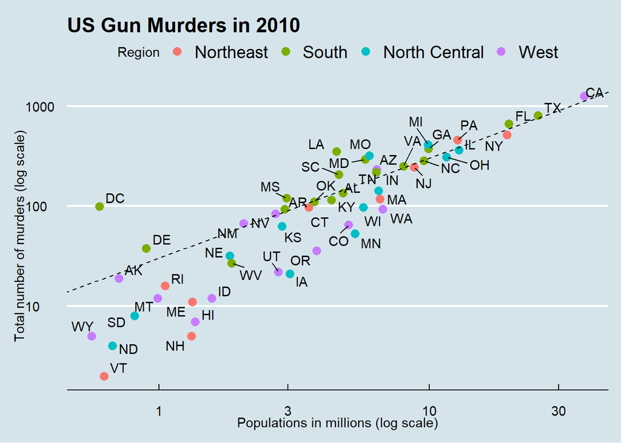

```r
murders %>% ggplot(aes(x = population/10^6, y = total, label = abb)) +
  geom_point(aes(
    col = region),
    size = 3
    ) +
  geom_abline(intercept = log10(r), lty = 2,) +
  geom_text_repel() +
  scale_x_log10() +
  scale_y_log10() +
  xlab("Populations in millions (log scale)") +
  ylab("Total number of murders (log scale)") +
  ggtitle("US Gun Murders in 2010") +
  scale_colour_discrete(name = "Region") +
  theme_economist()
```

Histogram divides span of data into non-overlapping bins of the e size. Then, for each bin, it counts the number of values that fall in that interval. The histogram plots these counts as bars with the base of the bar defined by the intervals.

Histograms answer questions such as uni/multimodality, symmetric/asymmetric distribution, 95% value range

geom_histogram() creates a histogram

bins define the number of bins to divide the x-axis into

after_stat() accesses and maps aesthetics to variables that are calculated after a statistical transformation has been applied to the data

density is the probability density of each bin calculated by the geom_histogram() geometry

geom_density() computes and draws a kernel density estimate, a smoothed version of the histogram

ggarrange() provides method of arranging multiple ggplots on the same page

labels define a list of labels to be added to the plots

vjust adjust the vertical position of each label

ncol defines the number of columns in the plot grid

nrow defines the number of rows in the plot grid

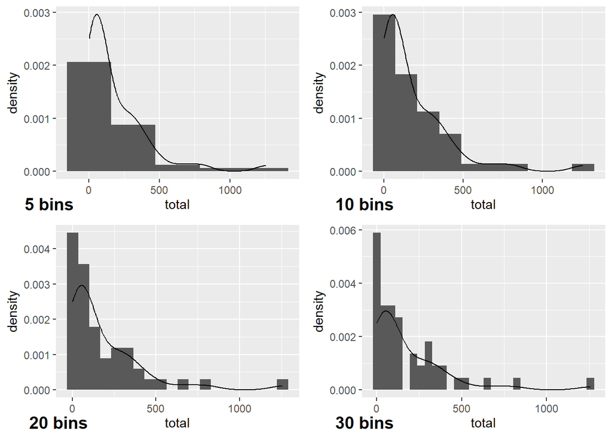

```r
bins_5 <- murders %>%
  ggplot(aes(x = total, y = after_stat(density))) +
  geom_histogram(bins = 5) +
  geom_density()

bins_10 <- murders %>%
  ggplot(aes(x = total, y = after_stat(density))) +
  geom_histogram(bins = 10) +
  geom_density()

bins_20 <- murders %>%
  ggplot(aes(x = total, y = after_stat(density))) +
  geom_histogram(bins = 20) +
  geom_density()

bins_30 <- murders %>%
  ggplot(aes(x = total, y = after_stat(density))) +
  geom_histogram(bins = 30) +
  geom_density()

ggarrange(bins_5, bins_10, bins_20, bins_30, labels=c("5 bins", "10 bins", "20 bins", "30 bins"), vjust=16.5, ncol = 2, nrow = 2)
```

R Markdown s a simple and easy to use plain text language used to combine your R code, results from your data analysis (including plots and tables) and written commentary into a single nicely formatted and reproducible document.

You can output RMD files into HTML, PDF, or Word

RMD is normally composed of (1) a YAML header, (2) formatted text, and (3) one or more code chunks

YAML header is surrounded before and after by a `---` delimeter on its own line and contains the metadata and options for the entire document such as the author name, date, output format, etc.

A simple YAML header may look like this:

`---`

`title: My first R markdown document`

`author: Jane Doe`

`date: November 04, 2024`

`output: pdf_document` (or html_document/word_document)

`---`

RMD can render almost) all the text formatting that you are likely to need such as italics, bold, strike-through, superscript and subscript as well as bulleted and numbered lists, headers and footers, images, links to other documents or web pages and even equations.

You need to “markup” the formatting in the RMD script to be rendered in your output document.

Some of the most common RMD syntax is: bold (`**text**`: **text**), italic (`*text*`: *text*), strikethrough (`~~text~~`: text), superscript (`text^2^`: text<sup>2</sup>), and subscript (`text~2~`: text<sub>2</sub>)

RMD generally ignores multiple spaces within the text. If you really want multiple spaces, use `&nbsp`. In PDF output, use `\\` and in HTML, use `<br>` for line breaks.

Headings and subheadings are added by using the # symbol at the beginning of the line. You can decrease the size of the headings by simply adding more # symbols.

If you want to include a comment in your R markdown document outside a code chunk which won’t be included in the final rendered document then enclose your comment between `<!--` and `-->`.

You can create an unordered list with “-”, “+”, or “*” and an ordered list with 1., 2., etc. Sub-items need to be indented.

Enclose the link text between square brackts and URL between round brackets immediately after `[link](https://www.imperial.ac.uk)`.

To make any url links have the distinct blue colour, add “urlcolour: blue” to the YAML header.

Problems with coding include backups, alternate versions (trying things out), rewinding, different versions for different people, merge changes from team, and merge conflicts (incompatible changes)

Version control is a system for tracking and managing changes to files (especially code) over time, allowing developers to revert to past versions, compare changes, and collaborate by merging different work streams safely

The following is the Git workflow:

- Create repository: `git init`
- Add files: `git add .`
- Create commit: `git commit -m 'new feature'`
- Share with remote repository: `git push origin main`
- Get others’ new change: `git pull origin main`

Making branches allow different versions of the repository to exist:

- Make a branch: `git checkout -b new_branch`
- Switch branches: `git checkout different_branck`
- Merge branches (inside “this_branch” run): `git merge other_branch` to “this_branch”

Github provides git repository hosting and is a useful online interface for viewing files, branches and merges

## Tutorial 5 (06/11/2025)

- **Overview**
  - fill
  - geom_vline
    - xintercept
  - panel.grid.major
  - panel.grid.minor
  - legend.position

### Tutorial Code

fill defines the fill colour of the plots

geom_vline draws a vertical line

xintercept defines the x-intercept, a single x-value where the vline is located at

linewidth defines the width of the line

panel.grid.major specifies major grid lines (primary divisions on axis)

panel.grid.minor specifies minor grid lines (finer detail between major lines)

legend.position defines the position of the legend

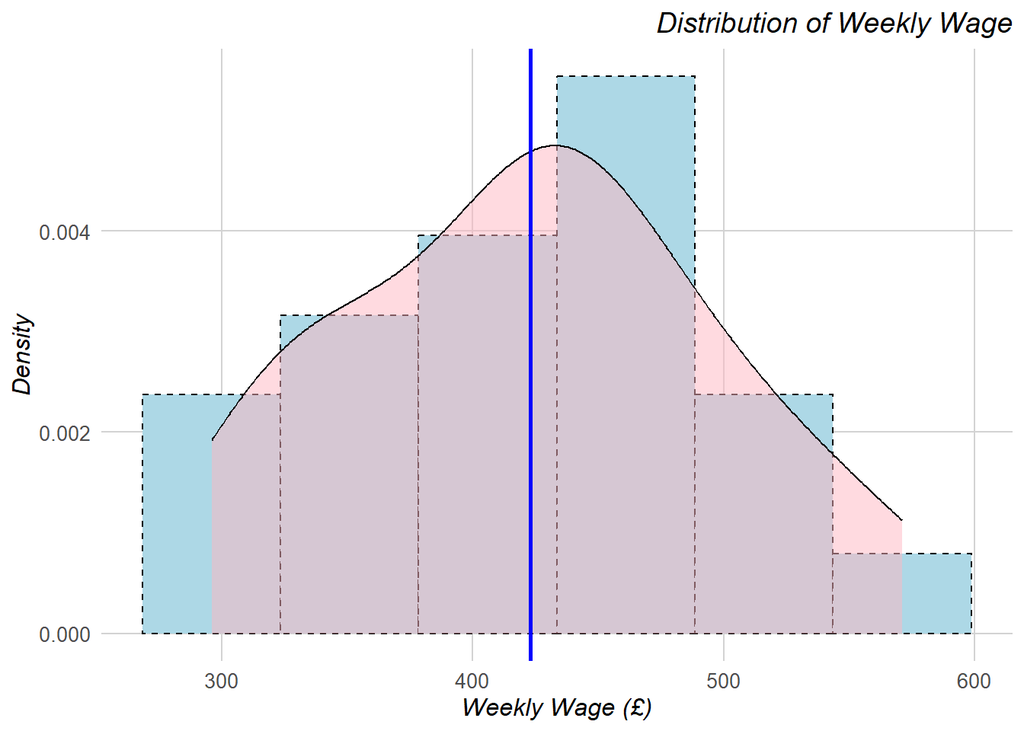

```r
setwd("C:/Users/slee7/OneDrive - Imperial College London/Introduction to Data Science/Week 5")
uk_gdp_and_weeklyWage <- read.csv("uk_gdp_and_weeklyWage2.csv",
                                  stringsAsFactors = F)

uk_gdp_and_weeklyWage %>%
  ggplot(aes(x = Weekly_pay, y = after_stat(density))) +
  geom_histogram(bins = 6, colour = "black", fill = "lightblue", linetype = "dashed") +
  geom_density(alpha = 0.5, fill = "lightpink") +
  geom_vline(aes(xintercept = mean(Weekly_pay)),
             colour = "blue", linetype = "solid", linewidth = 1) +
  labs(
    title = "Distribution of Weekly Wage",
    x = "Weekly Wage (£)",
    y = "Density"
    ) +
  theme_minimal() +
  theme(
    plot.title = element_text(hjust = 1.0, size = 14, face = "italic"),
    axis.text = element_text(size = 10),
    axis.title = element_text(size = 12, face = "italic"),
    panel.grid.major = element_line(colour = "lightgrey"),
    panel.grid.minor = element_blank(), # Remove minor grid lines
    legend.position = "none" # Remove legend
    )
```

### Additional Files

None!

## Lecture 6 (10/11/2025)

- **Overview**
  - High-level development loop
  - Low-level development loop
  - Data wrangling
  - Mutating joins
  - Filtering joins
  - Primary and foreign keys
  - count()
  - left_join()
    - join_by()
  - right_join()
  - full_join()
  - inner_join()
  - semi_join()
  - anti_join()
  - Wide and long format
  - system.file()
  - file.path()
  - gather()
    - convert
      - type.convert()
  - spread()
  - separate()
    - extra
  - unite()
  - rename()

High-Level Development Loop: find data, understand data, research question, hypothesis, evaluation

Low-Level Development Loop: make changes to code, run code, results/errors, evaluate/understand, plan next step

Data wrangling is needed to convert data from its raw form to the tidy form

Mutating joins add new variable to one data frame from matching observations in another (left_join, inner_join, right_join, full_join)

Filtering joins filter observations from one data frame based on whether or not they match an observation in another. It does not add new columns from the right table. (semi_join, anti_join)

Every join involves a primary key and a foreign key.

A primary key is a variable or set of variables that uniquely identifies each observation. When more than one variable is needed, the key is called a compound key.

A foreign key is a variable (or set of variables)that corresponds to a primary key in another table.

count() lets you count the unique values of one or more variables

Ideally your primary keys should all be unique (`df %>% count(primary_key) %>% filter (n > 1)` gives nothing) and should not contain missing values (`df %>% filter(is.na(primary_key))` gives nothing)

We will be using the nycflights13 package to demonstrate:

```r
flights2 <- flights %>% select(year, time_hour, origin, dest, tailnum, carrier)

head(flights2)
```

| year | time_hour | origin | dest | tailnum | carrier |
| --- | --- | --- | --- | --- | --- |
| 2013 | 2013-01-01 05:00:00 | EWR | IAH | N14228 | UA |
| 2013 | 2013-01-01 05:00:00 | LGA | IAH | N24211 | UA |
| 2013 | 2013-01-01 05:00:00 | JFK | MIA | N619AA | AA |
| 2013 | 2013-01-01 05:00:00 | JFK | BQN | N804JB | B6 |
| 2013 | 2013-01-01 06:00:00 | LGA | ATL | N668DN | DL |
| 2013 | 2013-01-01 05:00:00 | EWR | ORD | N39463 | UA |

```r
head(airlines)
```

| carrier | name |
| --- | --- |
| 9E | Endeavor Air Inc. |
| AA | American Airlines Inc. |
| AS | Alaska Airlines Inc. |
| B6 | JetBlue Airways |
| DL | Delta Air Lines Inc. |
| EV | ExpressJet Airlines Inc. |

```r
head(planes)
```

| tailnum | year | type | manufacturer | model | engines | seats | speed | engine |
| --- | --- | --- | --- | --- | --- | --- | --- | --- |
| N10156 | 2004 | Fixed wing multi engine | EMBRAER | EMB-145XR | 2 | 55 | NA | Turbo-fan |
| N102UW | 1998 | Fixed wing multi engine | AIRBUS INDUSTRIE | A320-214 | 2 | 182 | NA | Turbo-fan |
| N103US | 1999 | Fixed wing multi engine | AIRBUS INDUSTRIE | A320-214 | 2 | 182 | NA | Turbo-fan |
| N104UW | 1999 | Fixed wing multi engine | AIRBUS INDUSTRIE | A320-214 | 2 | 182 | NA | Turbo-fan |
| N10575 | 2002 | Fixed wing multi engine | EMBRAER | EMB-145LR | 2 | 55 | NA | Turbo-fan |
| N105UW | 1999 | Fixed wing multi engine | AIRBUS INDUSTRIE | A320-214 | 2 | 182 | NA | Turbo-fan |

```r
head(airports)
```

| faa | name | lat | lon | alt | tz | dst | tzone |
| --- | --- | --- | --- | --- | --- | --- | --- |
| 04G | Lansdowne Airport | 41.13047 | -80.61958 | 1044 | -5 | A | America/New_York |
| 06A | Moton Field Municipal Airport | 32.46057 | -85.68003 | 264 | -6 | A | America/Chicago |
| 06C | Schaumburg Regional | 41.98934 | -88.10124 | 801 | -6 | A | America/Chicago |
| 06N | Randall Airport | 41.43191 | -74.39156 | 523 | -5 | A | America/New_York |
| 09J | Jekyll Island Airport | 31.07447 | -81.42778 | 11 | -5 | A | America/New_York |
| 0A9 | Elizabethton Municipal Airport | 36.37122 | -82.17342 | 1593 | -5 | A | America/New_York |

All dplyr join functions take a pair of data frames (`x` and `y`) and return a data frame.

By writing `join_by(key)` within, you can specify which key to join the data frames by.

left_join() keeps all rows from the left table and adds matching columns from the right table

When left_join() fails to find a match for a row in the left data frame, it fills the right table variables (on the right) with missing values.

```r
left_join(flights2,airlines, join_by(carrier)) %>%
  head()
```

| year | time_hour | origin | dest | tailnum | carrier | name |
| --- | --- | --- | --- | --- | --- | --- |
| 2013 | 2013-01-01 05:00:00 | EWR | IAH | N14228 | UA | United Air Lines Inc. |
| 2013 | 2013-01-01 05:00:00 | LGA | IAH | N24211 | UA | United Air Lines Inc. |
| 2013 | 2013-01-01 05:00:00 | JFK | MIA | N619AA | AA | American Airlines Inc. |
| 2013 | 2013-01-01 05:00:00 | JFK | BQN | N804JB | B6 | JetBlue Airways |
| 2013 | 2013-01-01 06:00:00 | LGA | ATL | N668DN | DL | Delta Air Lines Inc. |
| 2013 | 2013-01-01 05:00:00 | EWR | ORD | N39463 | UA | United Air Lines Inc. |

right_join() keeps all observations in the right table and adds matching columns from the left table

When right_join() fails to find a match for a row in the left data frame, it fills the left table variables (on the left) with missing values.

full_join() keeps all observations that appear in the right or left table.

Every row of the right and left table is included and whenever there isn’t a match, the missing table’s variable is filled with missing values. As per convention, the output starts with all rows from the left table, followed by the unmatched right table rows.

inner_join() retains rows if and only if the keys are equal. Given there are no NA values in both tables to start, there are o NA values after inner_join.

semi_join() keeps all rows in the left table that have a match in the right table. However, it does not add new columns from the right table.

```r
semi_join(airports, flights2, join_by(faa == origin))
```

| faa | name | lat | lon | alt | tz | dst | tzone |
| --- | --- | --- | --- | --- | --- | --- | --- |
| EWR | Newark Liberty Intl | 40.69250 | -74.16867 | 18 | -5 | A | America/New_York |
| JFK | John F Kennedy Intl | 40.63975 | -73.77893 | 13 | -5 | A | America/New_York |
| LGA | La Guardia | 40.77725 | -73.87261 | 22 | -5 | A | America/New_York |

anti_join() keeps all rows in the left table that does not have a match in the right table. However, it does not add new columns from the right table.

```r
anti_join(flights2, airports, join_by(dest == faa)) %>%
  head()
```

| year | time_hour | origin | dest | tailnum | carrier |
| --- | --- | --- | --- | --- | --- |
| 2013 | 2013-01-01 05:00:00 | JFK | BQN | N804JB | B6 |
| 2013 | 2013-01-01 06:00:00 | JFK | SJU | N794JB | B6 |
| 2013 | 2013-01-01 06:00:00 | JFK | SJU | N3BAAA | AA |
| 2013 | 2013-01-01 07:00:00 | EWR | SJU | N77296 | UA |
| 2013 | 2013-01-01 07:00:00 | JFK | SJU | N651JB | B6 |
| 2013 | 2013-01-01 08:00:00 | JFK | SJU | N527JB | B6 |

In wide format, one observation has several components, which are in different columns. The observation types are stored in the column titles.

In long format, each component has been split out into its own observation. The observation types are stores in a single column.

This code loads the data needed. The system.file() is used to find the full file names (paths) of files and directories within installed packages. file.path() is used to construct file paths from individual components to be compatible across different operating systems.

```r
path <- system.file("extdata", package="dslabs")
filename <- file.path(path, "life-expectancy-and-fertility-two-countries-example.csv")
wide_data <- read_csv(filename, show_col_types = FALSE)
head(wide_data)
```

| country | 1960_fertility | 1960_life_expectancy | 1961_fertility | 1961_life_expectancy | 1962_fertility | 1962_life_expectancy | 1963_fertility | 1963_life_expectancy | 1964_fertility | 1964_life_expectancy | 1965_fertility | 1965_life_expectancy | 1966_fertility | 1966_life_expectancy | 1967_fertility | 1967_life_expectancy | 1968_fertility | 1968_life_expectancy | 1969_fertility | 1969_life_expectancy | 1970_fertility | 1970_life_expectancy | 1971_fertility | 1971_life_expectancy | 1972_fertility | 1972_life_expectancy | 1973_fertility | 1973_life_expectancy | 1974_fertility | … |
| --- | --- | --- | --- | --- | --- | --- | --- | --- | --- | --- | --- | --- | --- | --- | --- | --- | --- | --- | --- | --- | --- | --- | --- | --- | --- | --- | --- | --- | --- | --- |
| Germany | 2.41 | 69.26 | 2.44 | 69.85 | 2.47 | 70.01 | 2.49 | 70.10 | 2.49 | 70.66 | 2.48 | 70.65 | 2.44 | 70.77 | 2.37 | 70.99 | 2.28 | 70.64 | 2.17 | 70.48 | 2.04 | 70.72 | 1.92 | 70.94 | 1.80 | 71.16 | 1.70 | 71.41 | 1.62 | … |
| South Korea | 6.16 | 53.02 | 5.99 | 53.75 | 5.79 | 54.51 | 5.57 | 55.27 | 5.36 | 56.04 | 5.16 | 56.84 | 4.99 | 57.67 | 4.85 | 58.54 | 4.73 | 59.44 | 4.62 | 60.35 | 4.53 | 61.22 | 4.41 | 62.02 | 4.27 | 62.73 | 4.09 | 63.34 | 3.87 | … |

gather() reshapes data from a “wide” format to a “long” format.

- The first argument is the data frame.
- The second and third argument will tell gather the column names we want to assign to the column containing the current column names and the column containing the observations, respectively.
- The fourth argument specifies which columns to gather (default is all)

Gather function assumes column names are characters

convert will run the function type.convert() that converts a data object to logical, integer, numeric, complex, character or factor as appropriate.

You can also eliminate a column by putting a hyphen in front (“-country”).

```r
new_tidy_data <- gather(wide_data, key, value, `1960_fertility`:`2015_life_expectancy`, convert = TRUE)

# Alternatively do mutate(year = as.numeric(year))

head(new_tidy_data)
```

| country | key | value |
| --- | --- | --- |
| Germany | 1960_fertility | 2.41 |
| South Korea | 1960_fertility | 6.16 |
| Germany | 1960_life_expectancy | 69.26 |
| South Korea | 1960_life_expectancy | 53.02 |
| Germany | 1961_fertility | 2.44 |
| South Korea | 1961_fertility | 5.99 |

Since the raw data contains two variables, we need to separate the variables

The separate function takes three arguments: (1) the name of the column to be separated, (2) the names to be used for the new columns, and (3) the character that separates the variables.

extra = “merge” ensures that the last two variables are merged when there is an extra separation (otherwise, “life” and “expectancy” are broken up).

```r
new_tidy_data2 <- new_tidy_data %>%
  separate(key, c("year", "variable_name"), "_", extra = "merge")
head(new_tidy_data2)
```

| country | year | variable_name | value |
| --- | --- | --- | --- |
| Germany | 1960 | fertility | 2.41 |
| South Korea | 1960 | fertility | 6.16 |
| Germany | 1960 | life_expectancy | 69.26 |
| South Korea | 1960 | life_expectancy | 53.02 |
| Germany | 1961 | fertility | 2.44 |
| South Korea | 1961 | fertility | 5.99 |

We can also do the reverse of separate by uniting two columns into one.

fill=“right” tells R to fill with missing values on the right if there are not enough pieces to separate

```r
new_tidy_data3 <- new_tidy_data %>%
  separate(key, into = c("year", "first_variable_name", "second_variable_name"), sep = "_", fill = "right")

head(new_tidy_data3)
```

| country | year | first_variable_name | second_variable_name | value |
| --- | --- | --- | --- | --- |
| Germany | 1960 | fertility | NA | 2.41 |
| South Korea | 1960 | fertility | NA | 6.16 |
| Germany | 1960 | life | expectancy | 69.26 |
| South Korea | 1960 | life | expectancy | 53.02 |
| Germany | 1961 | fertility | NA | 2.44 |
| South Korea | 1961 | fertility | NA | 5.99 |

```r
new_tidy_data4 <- unite(new_tidy_data3, variable_name, first_variable_name, second_variable_name)

# Note how "fertility" and "NA" was joined to "fertility_NA"

head(new_tidy_data4)
```

| country | year | variable_name | value |
| --- | --- | --- | --- |
| Germany | 1960 | fertility_NA | 2.41 |
| South Korea | 1960 | fertility_NA | 6.16 |
| Germany | 1960 | life_expectancy | 69.26 |
| South Korea | 1960 | life_expectancy | 53.02 |
| Germany | 1961 | fertility_NA | 2.44 |
| South Korea | 1961 | fertility_NA | 5.99 |

Sometimes it is useful to convert long format into wide format. To do this, we use spread.

- The first argument is the data frame.
- The second argument tells which variable will be used as the column names.
- The third argument specifies which variable to use to fill out the cells.

rename(x=y) renames the column y into “x”

```r
spread(new_tidy_data4, variable_name, value) %>%
  rename(fertility = fertility_NA) %>%
  head()
```

| country | year | fertility | life_expectancy |
| --- | --- | --- | --- |
| Germany | 1960 | 2.41 | 69.26 |
| Germany | 1961 | 2.44 | 69.85 |
| Germany | 1962 | 2.47 | 70.01 |
| Germany | 1963 | 2.49 | 70.10 |
| Germany | 1964 | 2.49 | 70.66 |
| Germany | 1965 | 2.48 | 70.65 |

## Tutorial 6 (13/11/2025)

- **Overview**
  - pivot_longer()
  - pivot_wider()
  - rbind()
  - cbind()

### Tutorial Code

Create toy dataset

```r
exam_scores <- data.frame(
  student = c("Alice", "Bob", "Charlie"),
  math = c(85, 92, 78),
  english = c(90, 88, 82),
  science = c(88, 95, 80)
  )

exam_scores
```

| student | math | english | science |
| --- | --- | --- | --- |
| Alice | 85 | 90 | 88 |
| Bob | 92 | 88 | 95 |
| Charlie | 78 | 82 | 80 |

pivot_longer() converts data from wide to long format (turns multiple columns into key–value pairs). It does the same thing as gather().

```r
exam_scores_long <- pivot_longer(exam_scores,
                                 cols = math:science,
                                 names_to = "subject",
                                 values_to = "score")

exam_scores_long
```

| student | subject | score |
| --- | --- | --- |
| Alice | math | 85 |
| Alice | english | 90 |
| Alice | science | 88 |
| Bob | math | 92 |
| Bob | english | 88 |
| Bob | science | 95 |
| Charlie | math | 78 |
| Charlie | english | 82 |
| Charlie | science | 80 |

pivot_wider() converts data from long to wide format (spread key–value pairs into columns). It does the same thing as spread().

```r
exam_scores_wide <- exam_scores_long %>%
  pivot_wider(
    names_from = subject,
    values_from = score,
    names_prefix = "score_",
    values_fill = list(score = NA_real_), # missing combinations
    values_fn = list(score = ~mean(.x, na.rm = TRUE)) # handle duplicates
    )

exam_scores_wide
```

| student | score_math | score_english | score_science |
| --- | --- | --- | --- |
| Alice | 85 | 90 | 88 |
| Bob | 92 | 88 | 95 |
| Charlie | 78 | 82 | 80 |

rbind() stacks datasets vertically (rows) with the same columns.

```r
math_scores <- data.frame(
  student = c("Alice", "Bob"),
  score = c(85, 92)
  )

english_scores <- data.frame(
  student = c("Charlie", "Diana"),
  score = c(88, 90)
  )

all_scores <- rbind(math_scores, english_scores)

all_scores
```

| student | score |
| --- | --- |
| Alice | 85 |
| Bob | 92 |
| Charlie | 88 |
| Diana | 90 |

cbind() combines datasets horizontally (columns) with the same number of rows.

```r
students <- data.frame(
  student = c("Alice", "Bob", "Charlie")
  )

scores <- data.frame(
  score = c(85, 92, 88)
  )
students_scores <- cbind(students, scores)

students_scores
```

| student | score |
| --- | --- |
| Alice | 85 |
| Bob | 92 |
| Charlie | 88 |

### Additional Files

None!

## Lecture 7 (17/11/2025)

- **Overview**
  - Exploratory data analysis (EDA)
  - Variance
  - Covariance
  - Subgroups
  - coord_cartesian()
    - ylim
  - Unusual values
  - geom_freqpoly()
  - %%
  - %/%
  - geom_boxplot()
    - varwidth
  - geom_count()
  - geom_tile()
  - cut_width()

Exploratory Data Analysis (EDA) is the terminology used to describe the process of exploring data in a systematic way using visualisation and data transformation. The process involves:

- Generating questions about the data
- Searching for answers by visualising, transforming, and modelling your data
- Using what you learn to refine your questions and/or generate new questions

It is a creative process with a goal to develop an understanding of your data. The best way to understand patterns is to visualize the distribution of the variable’s values. Two types of questions guide discovery:

- What type of variation occurs within my variables?
- What type of covariation occurs between my variables?

Variation is the tendency of the values of a variable to change from measurement to measurement.

Visualization can reveal clusters, suggesting subgroups exist within the data. To understand subgroups, ask:

- How are the observations within each subgroup similar to each other?
- How are the observations in separate clusters different from each other?
- How can you explain or describe the clusters?
- Why might the appearance of clusters be misleading?

We will use the ggplot2’s diamonds database:

```r
head(diamonds)
```

| carat | cut | color | clarity | depth | table | price | x | y | z |
| --- | --- | --- | --- | --- | --- | --- | --- | --- | --- |
| 0.23 | Ideal | E | SI2 | 61.5 | 55 | 326 | 3.95 | 3.98 | 2.43 |
| 0.21 | Premium | E | SI1 | 59.8 | 61 | 326 | 3.89 | 3.84 | 2.31 |
| 0.23 | Good | E | VS1 | 56.9 | 65 | 327 | 4.05 | 4.07 | 2.31 |
| 0.29 | Premium | I | VS2 | 62.4 | 58 | 334 | 4.20 | 4.23 | 2.63 |
| 0.31 | Good | J | SI2 | 63.3 | 58 | 335 | 4.34 | 4.35 | 2.75 |
| 0.24 | Very Good | J | VVS2 | 62.8 | 57 | 336 | 3.94 | 3.96 | 2.48 |

Outliers are observations that are unusual.

Here, the only evidence of outliers is the unusually wide limits on the x-axis.

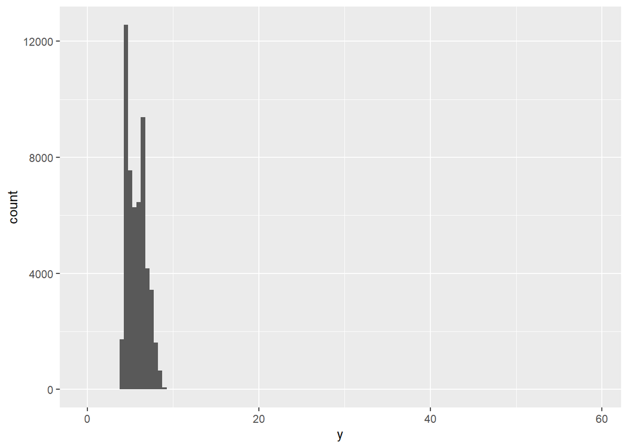

```r
diamonds %>%
  ggplot(aes(x = y)) +
  geom_histogram(binwidth = 0.5)
```

coord_cartesian() sets the x,y clips for the graph

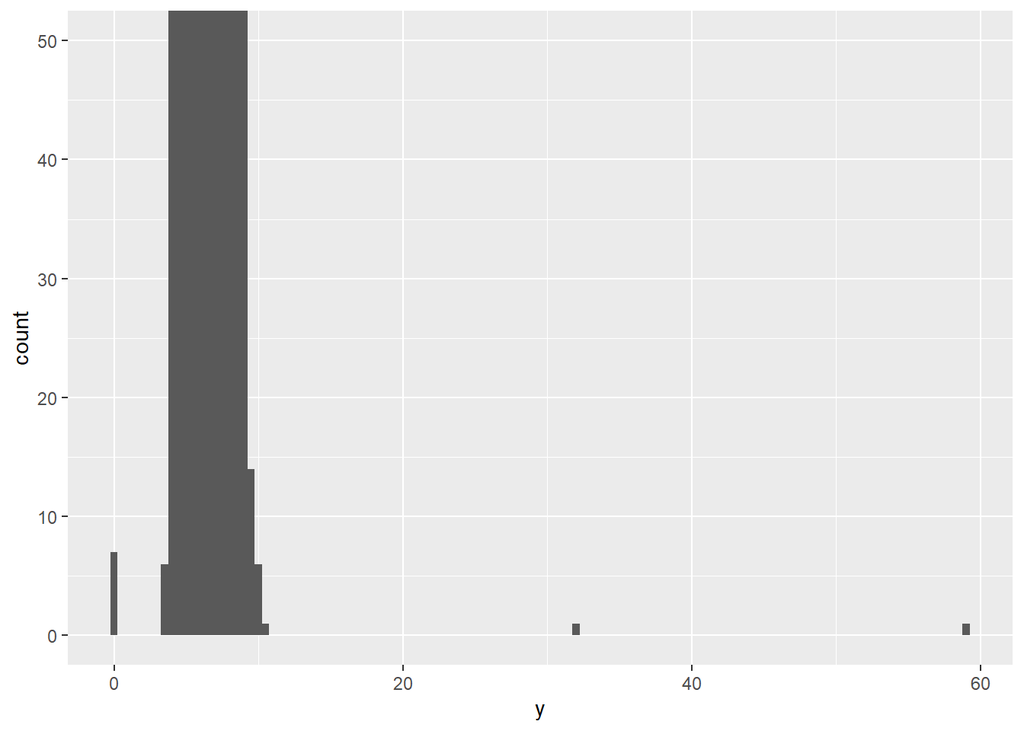

```r
diamonds %>%
  ggplot(aes(x = y)) +
  geom_histogram(binwidth = 0.5) +
  coord_cartesian(ylim = c(0,50))
```

We see unusual values at 0, ~30, and ~60. We can select them:

```r
diamonds %>%
  filter(y < 3 | y > 20) %>%
  select(price, x, y, z) %>%
  arrange(y)
```

| price | x | y | z |
| --- | --- | --- | --- |
| 5139 | 0.00 | 0.0 | 0.00 |
| 6381 | 0.00 | 0.0 | 0.00 |
| 12800 | 0.00 | 0.0 | 0.00 |
| 15686 | 0.00 | 0.0 | 0.00 |
| 18034 | 0.00 | 0.0 | 0.00 |
| 2130 | 0.00 | 0.0 | 0.00 |
| 2130 | 0.00 | 0.0 | 0.00 |
| 2075 | 5.15 | 31.8 | 5.12 |
| 12210 | 8.09 | 58.9 | 8.06 |

Through EDA, we found out possible NA values (0 mm doesn’t exist) and possible errors (32mm and 59mm diamonds that are cheap).

If you encounter unusual values in your dataset, you can drop the entire row with the strange values (not recommended) or replace with missing values:

```r
diamonds2 <- diamonds %>%
  mutate(y = if_else(y < 3 | y > 20, NA, y))
```

If you plot this data with missing values, ggplot ignores those rows but gives a warning that there are missing values

`%%` indicates `x mod y` and `%/%` indicates integer division.

geom_freqpoly() creates a density plot that connects the middle of a histogram chart with lines

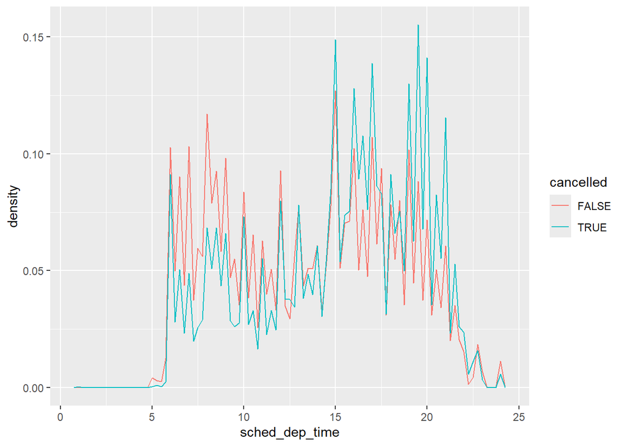

```r
new <- nycflights13::flights %>%
  mutate(
    cancelled = is.na(dep_time),
    sched_hour = sched_dep_time %/% 100,
    sched_min = sched_dep_time %% 100,
    sched_dep_time = sched_hour + (sched_min / 60))

new %>%
  ggplot(aes(x = sched_dep_time, after_stat(density))) +
  geom_freqpoly(aes(colour = cancelled), binwidth = 1/4)
```

Covariation is the tendency for the values of two or more variables to vary together in a related way.

geom_boxplot() gives a box and whiskers plot depicting the range, Q1, median, Q3, and outliers

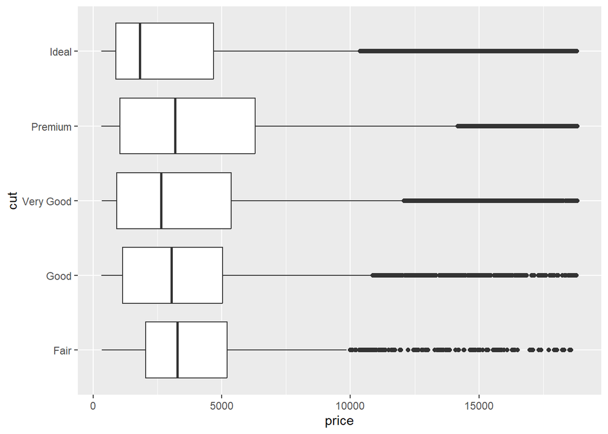

```r
ggplot(diamonds2, aes(x = price, y = cut)) +
  geom_boxplot()
```

geom_count() gives the number of observations at each location, then maps the count to the size of the points

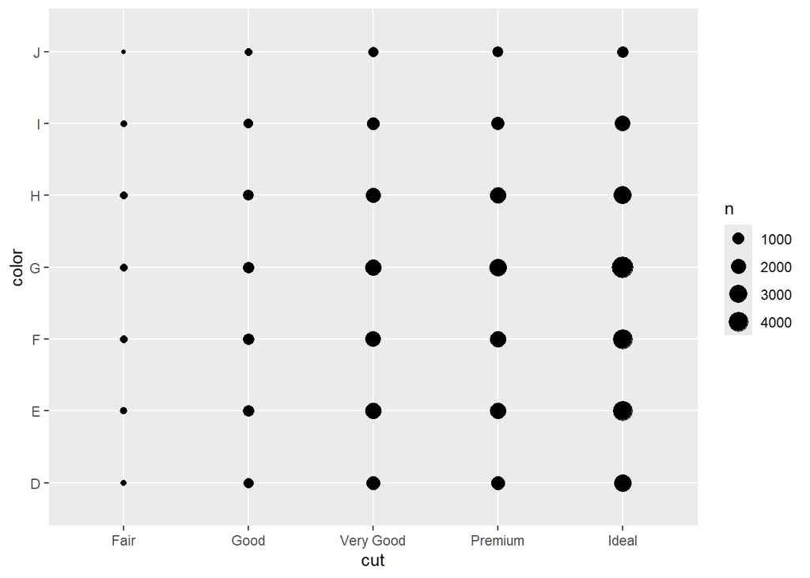

```r
ggplot(diamonds2, aes(x = cut, y = color)) +
  geom_count()
```

geom_tile() creates a tiled heat map

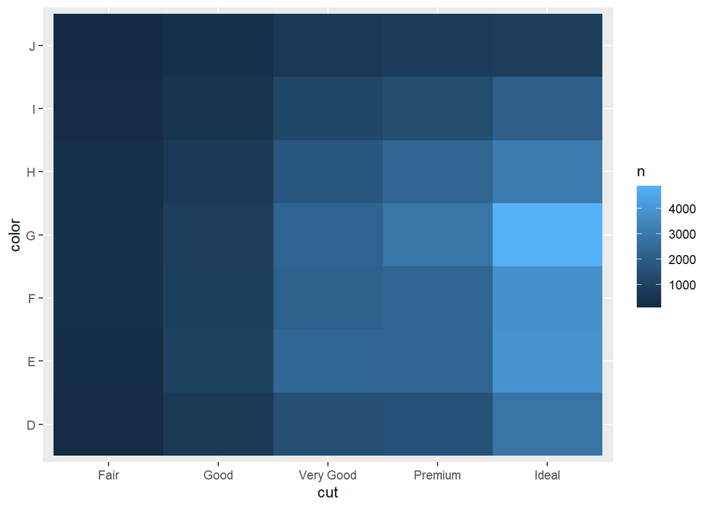

```r
diamonds2 %>%
  count(color, cut) %>%
  ggplot(aes(x = cut, y = color)) +
  geom_tile(aes(fill = n))
```

cut_width() discretizes a continuous numeric variable into a categorical one by creating bins

aes group makes the geometry plot graphs for each group

varwidth makes the width of the boxplot proportional to the number of points

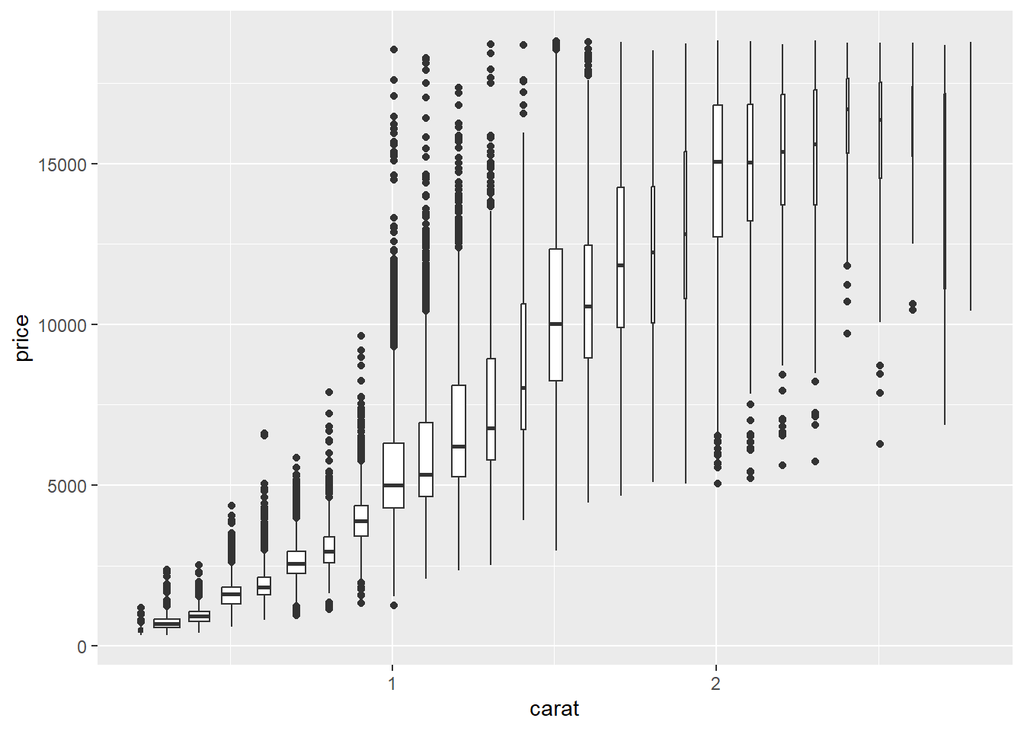

```r
diamonds2 %>%
  filter(carat < 3) %>%
  ggplot(aes(x = carat, y = price)) +
  geom_boxplot(aes(group = cut_width(carat, 0.1)),
               varwidth = TRUE)
```

## Tutorial 7 (20/11/2025)

- **Overview**
  - as.numeric()
  - colnames()
  - Multiple by= in joins
  - scale_x_continuous()
    - limits
    - breaks
  - scale_colour_manual()
  - scale_shape_manual()
  - scale_linetype_manual()
  - scale_fill_manual()
  - rowid_to_column()
  - drop_na()
  - distinct()
  - colSums()
  - which()
  - apply()
    - arr.ind
  - add_column()

### Tutorial Code

Load required datasets

```r
setwd("C:/Users/slee7/OneDrive - Imperial College London/Introduction to Data Science/Week 7")

Eng_population <- read.csv("./data2/ONS-England_population.csv", stringsAsFactors = F)

Wales_population <- read.csv("./data2/ONS-Wales_population.csv", stringsAsFactors = F)

Eng_Wales_GDP_GR <- read.csv("./data2/ONS-England-Wales_GDP_GrowthRate.csv", stringsAsFactors = F)
```

as.numeric() converts object into numeric type

colnames() retrieves or sets the column names of matrix-like objects such as data frames and matrices

We correct the data as follows:

```r
Eng_population <- Eng_population[8:58,]
colnames(Eng_population) <- c("Year", "Population")
Eng_population <- Eng_population %>%
  mutate(Year = as.numeric(Year),
         Population = as.numeric(Population),
         Region = "England")

Wales_population <- Wales_population[8:58,]
colnames(Wales_population) <- c("Year", "Population")
Wales_population <- Wales_population %>%
  mutate(Year = as.numeric(Year),
         Population = as.numeric(Population),
         Region = "Wales")

Eng_Wales_population <- rbind(Eng_population, Wales_population)

head(Eng_Wales_population)
```

|  | Year | Population | Region |
| --- | --- | --- | --- |
| 8 | 1971 | 46411700 | England |
| 9 | 1972 | 46571900 | England |
| 10 | 1973 | 46686200 | England |
| 11 | 1974 | 46682700 | England |
| 12 | 1975 | 46674400 | England |
| 13 | 1976 | 46659900 | England |

We can specify multiple columns to join by through c(“column1 from x” = “column1 from y”, “column2 from x” = “column2 from y”…). Only the columns from the x data frame remains.

```r
inner_join_data1 <- Eng_Wales_GDP_GR %>%
  inner_join(Eng_Wales_population,
             by = c("calendar.years" = "Year",
                    "Geography" = "Region")
             )

head(inner_join_data1)
```

|  | GrowthRate | calendar.years | Time | nuts | Geography | sic.unofficial | UnofficialStandardIndustrialClassification | type.of.prices | note | Population |
| --- | --- | --- | --- | --- | --- | --- | --- | --- | --- | --- |
| 1 | NA | 2012 | 2012 | UKL | Wales | A--T | A-T: Total | cvm | Annual growth rate | 3074100 |
| 2 | 3.4 | 2014 | 2014 | UK0 | England | A--T | A-T: Total | cvm | Annual growth rate | 54316600 |
| 3 | 2.3 | 2016 | 2016 | UK0 | England | A--T | A-T: Total | cvm | Annual growth rate | 55268100 |
| 4 | -10.6 | 2020 | 2020 | UK0 | England | A--T | A-T: Total | cvm | Annual growth rate | 56550000 |
| 5 | 1.7 | 2019 | 2019 | UK0 | England | A--T | A-T: Total | cvm | Annual growth rate | 56287000 |
| 6 | 8.3 | 2021 | 2021 | UKL | Wales | A--T | A-T: Total | cvm | Annual growth rate | 3105400 |

scale_x_continuous() can define the length of the x-axis (limits) and the axis ticks (breaks)

scale_colour_manual() sets the mappings from data to colour

scale_shape_manual() sets the mappings from data to shape

scale_linetype_manual() sets the mappings from data to linetype

scale_fill_manual() sets the mappings from data to fill

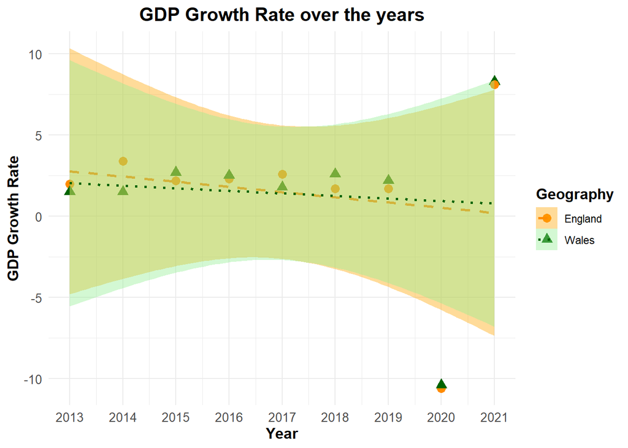

```r
inner_join_data1 %>%
  ggplot(aes(x = calendar.years, y = GrowthRate)) +
  geom_point(aes(colour = Geography, shape = Geography), size = 3) +
  geom_smooth(method = "lm", aes(colour = Geography, fill = Geography, lty = Geography)) +
  labs(x = "Year", y = "GDP Growth Rate", title = "GDP Growth Rate over the years") +
  theme_minimal() +
  theme(
    axis.title = element_text(size = 12, face = "bold"),
    axis.text = element_text(size = 10),
    plot.title = element_text(hjust = 0.5, size = 15, face = "bold"),
    legend.title = element_text(size = 12, face = "bold")
    ) +
  scale_x_continuous(breaks = 2013:2021,
                     limits = c(2013, 2021)
                     ) +
  scale_colour_manual(values = c("England" = "darkorange",
                                "Wales" = "darkgreen")) +
  scale_shape_manual(values = c("England" = 16,
                                "Wales" = 17)) +
  scale_linetype_manual(values = c("England" = "dashed",
                                   "Wales" = "dotted")) +
  scale_fill_manual(values = c("England" = "orange",
                               "Wales" = "lightgreen"))
```

### Additional Files

We will use the airquality dataset

```r
data("airquality")

head(airquality)
```

|  | Ozone | Solar.R | Wind | Temp | Month | Day |
| --- | --- | --- | --- | --- | --- | --- |
| 1 | 41 | 190 | 7.4 | 67 | 5 | 1 |
| 2 | 36 | 118 | 8.0 | 72 | 5 | 2 |
| 3 | 12 | 149 | 12.6 | 74 | 5 | 3 |
| 4 | 18 | 313 | 11.5 | 62 | 5 | 4 |
| 5 | NA | NA | 14.3 | 56 | 5 | 5 |
| 6 | 28 | NA | 14.9 | 66 | 5 | 6 |

rowid_to_column() converts row numbers into an explicit column

drop_na() removes rows with any NA in any column and can be restricted to looking at specific columns

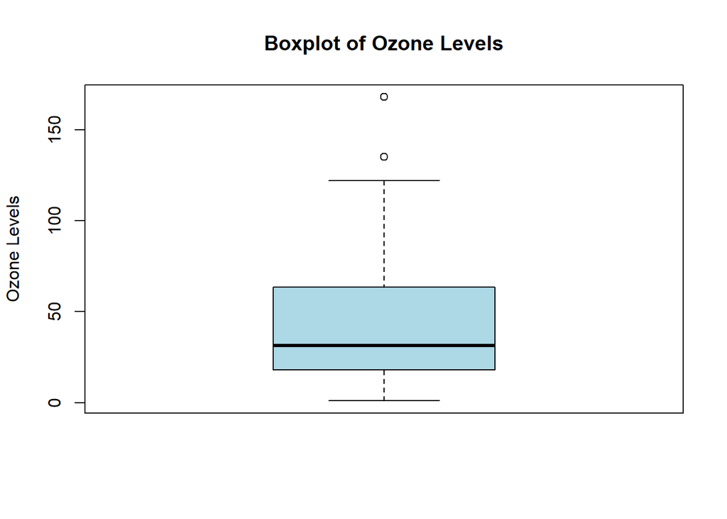

```r
airquality <- airquality %>%
  rowid_to_column("Index") %>%
  drop_na(Ozone) # Only looks for NA in Ozone column

boxplot(airquality$Ozone,
        main = "Boxplot of Ozone Levels",
        ylab = "Ozone Levels",
        col = "lightblue")
```

distinct() only keeps unique/distinct rows in a data frame

```r
ozone_with_outliers <- airquality %>%
  mutate(
    Q1 = quantile(Ozone, 0.25),
    Q3 = quantile(Ozone, 0.75),
    IQR = Q3 - Q1,
    Lower_Bound = Q1 - 1.5 * IQR,
    Upper_Bound = Q3 + 1.5 * IQR,
    Is_Outlier = if_else(Ozone < Lower_Bound | Ozone > Upper_Bound, "Outlier", "Not outlier")
    )

ozone_with_outliers %>%
  select(Q1, Q3, IQR, Lower_Bound, Upper_Bound) %>%
  distinct()
```

| Q1 | Q3 | IQR | Lower_Bound | Upper_Bound |
| --- | --- | --- | --- | --- |
| 18 | 63.25 | 45.25 | -49.875 | 131.125 |

```r
setwd("C:/Users/slee7/OneDrive - Imperial College London/Introduction to Data Science/Week 7")

uk_gdp_and_weeklyWage <- read.csv("data/uk_gdp_and_weeklyWage.csv", stringsAsFactors = F)
```

colSums() calculate the sum of each column

which() returns the position of values that meet a specific logical condition

```r
uk_gdp_and_weeklyWage %>% select(which(colSums(is.na(.)) > 0))
```

| GDP_m |
| --- |
| 1627447 |
| 1662558 |
| 1691998 |
| 1744840 |
| NA |
| 1833406 |
| 1873015 |
| 61319100 |
| 1918064 |
| 1831550 |

[output cut: 13 more lines]

The following function detects outliers (1.5 times IQR)

```r
detect_outlier <- function(x) {
  Q1 <- quantile(x, probs=.25, na.rm = T)
  Q3 <- quantile(x, probs=.75, na.rm = T)
  IQR = Q3-Q1
  result <- x > Q3 + (IQR*1.5) | x < Q1 - (IQR*1.5)
  return(result)
}
```

apply() returns values obtained by applying a function to a specified margin (1 is rows, 2 is columns, and c(1,2) is rows and columns).

arr.ind returns row and column index instead of a linear index

add_column() adds a column with name-value pairs

```r
NAs_loc <- which(uk_gdp_and_weeklyWage %>%
apply(., MARGIN = 2, is.na) , arr.ind = T)

outliers <- data.frame(rows=c(), cols=c())
outliers <- outliers %>% add_column(rows = NA, cols = NA)

outliers <- which(uk_gdp_and_weeklyWage %>%
apply(., MARGIN = 2, detect_outlier), arr.ind = T) %>%
  data.frame()

outliers_NAs <- rbind(outliers, NAs_loc)

outliers_NAs
```

| row | col |
| --- | --- |
| 8 | 3 |
| 17 | 3 |
| 8 | 4 |
| 17 | 4 |
| 5 | 3 |
| 14 | 3 |
| 20 | 3 |